# Econometria Aplicada à Finanças Aula 1

Mestrado Profissional em Administração

Prof. Dr. Washington S. da Silva

IFMG — Campus Formiga

4 de agosto de 2026

## Nesta Aula

**Tópicos**

- Apresentação da Disciplina
- Alguns conceitos básicos de inferência estatística
- Fundamento Teórico do Modelo de Regressão linear
- O Modelo de Regressão linear Simples
- Mínimos Quadrados ordinários (MQO)
- Propriedades dos Estimadores de MQO
- Atividade Prática 1

## Referência para a disciplina

**[Portaria CAPES nº 60/2019](https://cad.capes.gov.br/ato-administrativo-detalhar?idAtoAdmElastic=884)**

Art. 2º São objetivos dos cursos de mestrado e doutorado profissionais:

I - capacitar profissionais qualificados para práticas **avançadas**, **inovadoras** e **transformadoras dos processos de trabalho**, visando atender às demandas sociais, econômicas e organizacionais dos diversos setores da economia;

$\vdots$

III - contribuir para **agregação de conhecimentos** de forma a **impulsionar o aumento da produtividade em empresas**, organizações **públicas** e **privadas**;

IV – atentar aos **processos e procedimentos de inovação**, seja em atividades industriais geradoras de produtos, quanto na organização de serviços públicos ou privados;

$\vdots$

## Alinhamento de Expectativas

**O papel ativo do mestrando**

- **Aprender a aprender:** estudar de modo ativo.
- **Autonomia:** organizar o próprio trabalho, identificar lacunas, buscar fontes qualificadas, elaborar tentativas de solução…
- **Desenvolver sofisticação técnica:** usar R, Quarto, Git e GitHub de modo progressivamente mais fluente para produzir análises claras, reproduzíveis e passíveis de verificação.
- **Colaborar com responsabilidade:** trocar ideias e soluções, sem delegar a terceiros a compreensão, a execução ou a justificativa das próprias análises.

# Apresentação da Disciplina

## O que a Econometria faz?

**Visão Tradicional**

- Uma teoria propõe como variáveis podem estar relacionadas.
- Dados e métodos estatísticos permitem transformar essa ideia em análise empírica.
- A Econometria permite:
  - **estimar** parâmetros desconhecidos e quantificar relações;
  - **testar** hipóteses e restrições propostas por um modelo.
  - **prever** resultados condicionais à informação disponível;
- Ela responde perguntas sobre magnitude: não apenas se duas variáveis se relacionam, mas quanto uma relação estimada representa e quão precisa ela é.

## Do modelo teórico ao modelo econométrico

**Do CAPM à regressão**

Como descrito no slide anterior, partimos de uma teoria sobre a relação entre variáveis.

No modelo teórico do CAPM, o retorno excedente **esperado** de um ativo é proporcional ao retorno excedente esperado da carteira de mercado:

$$E\!\left(R_i-R_f\right)
=
\beta_i\,E\!\left(R_M-R_f\right),
\qquad
\beta_i=
\frac{\operatorname{Cov}(R_i,R_M)}{\operatorname{Var}(R_M)}.$$

Para confrontar essa relação com retornos observados ao longo do tempo, usa-se a regressão linear simples:

$$R^e_{i,t}=\alpha_i+\beta_iR^e_{M,t}+\varepsilon_{i,t},
\qquad
R^e_{i,t}=R_{i,t}-R_{f,t},\quad
R^e_{M,t}=R_{M,t}-R_{f,t}.$$

Na regressão, $\beta_i$ representa a exposição do ativo ao retorno excedente do mercado. Para os retornos esperados, o CAPM implica também a restrição $\alpha_i=0$.

## Perguntas empíricas em Finanças

**Envolvendo modelos de regressão**

- O modelo CAPM ou os modelos multifatoriais explicam melhor a variação dos retornos dos ativos? *(Comparação empírica de modelos de apreçamento de ativos.)*
- Quais características das empresas estão associadas à probabilidade de inadimplência ou default corporativo?
- Quais fatores específicos de empresas de capital aberto estão associados ao seu nível ESG?
- Quais características das empresas estão associadas à escolha entre financiamento via dívida ou emissão de ações?
- Firmas com maior investimento em inovação (R&D) apresentam maior valor de mercado ajustado ao risco?
- Empresas com maior presença de mulheres na liderança apresentam desempenho financeiro superior?

## O que a Econometria faz?

**Visão Moderna: Causalidade x Previsão**

- Uma variável pode ajudar a prever $y$ sem que uma mudança nessa variável cause uma mudança em $y$.
- **Previsão:** o foco é a acurácia das previsões ($\hat{y}$), variáveis podem ser indicadores ou proxies úteis, mesmo sem interpretação causal.
- **Causalidade:** o foco é estimar um parâmetro ($\hat{\beta}$) como efeito de modificar $x$. (Angrist e Pischke, 2010)
  - É preciso enfrentar o problema da **endogeneidade** nesse caso
- Uma regressão pode descrever uma **associação** entre variáveis, mas não estima, por si só, um efeito causal. Essa interpretação exigiria uma estratégia de **identificação** e hipóteses adicionais; voltaremos a esse problema adiante.

## Como os dados são gerados?

**Três desenhos de geração de dados**

- **Dados experimentais:** o pesquisador define uma intervenção e distribui aleatoriamente as unidades entre as condições ou grupos de tratamento.
- **Dados quase-experimentais:** uma política, regra ou evento cria um grupo exposto ao tratamento e um grupo de comparação, mas as unidades não são designadas aleatoriamente aos grupos.
- **Dados observacionais:** o pesquisador registra as variáveis tal como são geradas no ambiente econômico, social ou financeiro; não fixa seus valores nem designa a exposição ao tratamento.
- Dados financeiros são predominantemente **observacionais**. Logo, a plausibilidade da **exogeneidade** deve ser examinada antes de interpretar uma relação como causal.

## Um experimento

**Bertrand e Morse (2011)**

Informações formuladas à luz da psicologia podem reduzir o uso de crédito de alto custo? Em lojas de crédito de curto prazo (*payday loans*), o estudo comparou a divulgação usual com materiais que apresentavam os custos do empréstimo de formas distintas. Em um dos tratamentos, o material tornava saliente, em dólares, o custo acumulado de renovar o empréstimo:

| Grupo | Informação recebida |
| --- | --- |
| Tratado | Custos em dólares acumulados nas renovações |
| Comparação | Divulgação usual de custos |

Os clientes foram atribuídos aleatoriamente aos grupos e, portanto, eram comparáveis, em média, antes da intervenção. Esse tratamento reduziu em 11% a contratação de novos empréstimos nos quatro meses seguintes; sob as hipóteses do experimento, essa diferença tem interpretação causal.

## Um quase-experimento

**Card e Krueger (1994)**

Em 1992, a elevação do salário mínimo em New Jersey permitiu comparar restaurantes de fast-food em duas regiões:

| Grupo | Restaurantes | Salário mínimo em 1992 |
| --- | --- | --- |
| Tratado | New Jersey | Aumento |
| Comparação | Leste da Pensilvânia | Sem alteração |

A designação aos grupos ocorreu pela localização, e não por sorteio. Portanto, diferenças preexistentes entre as regiões podem ser confundidas com o efeito da política.

## Estruturas de dados econométricos

**Tradicionais**

| Estrutura | Observações | Exemplo financeiro |
| --- | --- | --- |
| **Corte transversal** | Unidades distintas em um período | Empresas ou fundos em uma data. |
| **Séries temporais** | A mesma grandeza em intervalos regulares | Retornos diários ou taxas de juros. |
| **Painel** | Unidades acompanhadas ao longo do tempo | Empresas em vários períodos. |

- A estrutura dos dados afeta as hipóteses e os procedimentos adequados.
- Nesta disciplina, estimaremos regressões com dados de corte transversal e séries temporais.
- Vejamos a estrutura típica destes dados.

## Dados em corte transversal (*cross-section data*)

**Estrutura do arquivo de dados**

| empresa | lucro | ativo | divida |
| --- | --- | --- | --- |
| A | 500 | 2000 | 1500 |
| B | 600 | 2200 | 1600 |
| C | 550 | 2100 | 1550 |

## Dados para regressão com séries temporais

**Uma relação observada repetidamente no tempo**

| data | retorno_excesso_acao | retorno_excesso_mercado |
| --- | --- | --- |
| 2024-01-31 | 0.021 | 0.018 |
| 2024-02-29 | -0.014 | -0.012 |
| 2024-03-28 | 0.027 | 0.019 |

Cada linha é uma data. Para uma mesma ação, observamos o retorno em excesso do ativo e o retorno em excesso do mercado. Esses pares $(R^e_{i,t}, R^e_{M,t})$ permitem estimar uma regressão temporal.

## Análise crível

**O modelo não é apenas uma equação**

Uma análise econométrica crível requer:

- hipóteses transparentes;
- um desenho de pesquisa coerente com os dados disponíveis;
- dados documentados;
- análise reprodutível (código e controle de versão)
- diagnósticos adequados.

## Da pergunta ao modelo de regressão

**Um fluxo comum de análise**

1. Começar por uma pergunta clara de pesquisa e uma justificativa teórica.
2. Especificar o modelo econômico e econométrico: resultado, variáveis explicativas, forma funcional e hipóteses.
3. Obter, documentar, organizar e pré-processar os dados: fontes, valores ausentes, observações atípicas e transformações.
4. Estimar os parâmetros, frequentemente por MQO em modelos lineares.
5. Diagnosticar ajuste e hipóteses do modelo: resíduos, heterocedasticidade e outros aspectos.
6. Interpretar os resultados de acordo com a pergunta de pesquisa; avaliar efeitos causais ou produzir previsões, apenas quando as hipóteses e o desenho de pesquisa os justificarem.

## Como trabalharemos com R, Quarto e Git?

**Uma análise deve ser transparente e reproduzível (Christensen e Miguel, 2018)**

- Scripts em R organizam e executam a obtenção, transformação e análise dos dados, bem como a estimação dos modelos.
- Arquivos Quarto integram código, narrativa, tabelas e figuras para documentar o fluxo de análise e comunicar resultados.
- Git e GitHub permitem controlar versões e preservar o histórico dos arquivos.
- Reprodutibilidade não substitui julgamento econométrico, ela permite examinar e refazer o caminho percorrido.

## O que um econometrista aplicado precisa saber?

**Nota**

Um econometrista aplicado combina, pelo menos, quatro competências:

1. A **Teoria econômica/financeira.**
2. A **Teoria estatística/econométrica.** (hipóteses, métodos e limitações).
3. A **aplicação desses métodos a dados reais**, articulando teoria e evidência empírica.
4. **Práticas e ferramentas para trabalhar com dados**: aquisição, transformação, junção, sumarização, visualização e modelagem;
- 4.1 programação e controle de versão.

Esta disciplina busca aprofundar as competências dos itens **2, 3 e 4**.

## Site da Disciplina

**URL**

- [Link para o Site da Disciplina](https://washingtonsilva.github.io/site_mpa_ecnt01_2026/)

# Alguns conceitos básicos de inferência estatística

## Inferência Estatística

**Definição**

#### **Por que é necessária?**:

Na maioria das vezes, não é possível coletar dados de toda a população, então usamos amostras para fazer inferências sobre a população como um todo.

#### **Inferência Estatística**:

Permite inferir características da população a partir da amostra, como médias, variâncias, proporções, etc.

#### **Objetivo**:

Estimar parâmetros populacionais, testar hipóteses e fazer previsões sobre a população com base em dados amostrais.

Nosso interesse nesta revisão, é sobretudo revisar estimadores pontuais e propriedades desejáveis destes estimadores.

## Métodos de Inferência Estatística

**Tipos**

Os métodos clássicos de Inferência Estatística podem ser divididos em:

#### Métodos de **Estimação de Parâmetros**:

- Estimação **Pontual**: envolve o uso de dados amostrais para estimar um parâmetro “populacional”. **Estimadores pontuais** são construídos para estimar parâmetros populacionais.
- Estimação **Intervalar**: Fornece um intervalo de valores que pode conter o verdadeiro parâmetro populacional. Um intervalo de confiança contém informações não apenas sobre a localização de um parâmetro, mas também sobre a **precisão** com que o estimamos.

#### **Testes de Hipóteses**:

Procedimentos para testar ou tomar uma decisão sobre se uma afirmação sobre um parâmetro populacional pode ser verdadeira com base nos dados da amostra.

## Notação e Conceitos

|  | População | Amostra |
| --- | --- | --- |
| Símbolos | $\mu$, $\sigma^2$, $p$, $\rho$ | $\bar{x}$, $s^2$, $\hat{p}$, $r$ |
| Fixo ou aleatório? | Fixo (desconhecido) | Aleatório |
| Obtido por | Censo/dados históricos | Amostragem |
| Objetivo | Verdade a descobrir | Instrumento de inferência |

## Conceitos Centrais

**Estimador, Estatística e Estimativa**

- **Estimador**: Fórmula que aplicamos aos dados da amostra para obter um valor que estima uma parâmetro populacional.
- **Estimativas**: Resultados numéricos obtidos ao aplicar os estimadores.
- **Estatística**: É qualquer função dos dados da amostra. Todo estimador é uma estatística, mas nem toda estatística é um **bom** estimador.

## Distinção Fundamental

### Estimador

- **variável aleatória**
- **Natureza**: Função dos dados
- **Varia**: Entre amostras
- **Exemplo**: $\bar{X} = \frac{\sum X_i}{n}$
- **Distribuição**: Tem sua própria distribuição (**distribuição amostral**)

### Estimativa

- **É**: Um **número fixo**
- **Natureza**: Valor calculado
- **Fixo**: Para uma amostra específica
- **Exemplo**: $\bar{x} = 7.82$
- **Interpretação**: Realização de um estimador ou estatística

## Quiz

**Identifique: Parâmetro, Estimador/Estatística ou Estimativa?**

Uma empresa de e-commerce analisa seus pedidos:

1. A fórmula $s^2 = \frac{\sum_{i=1}^{n}(X_i - \bar{X})^2}{n-1}$ para calcular variância
2. O valor R$ 127,50 calculado como média de 1.000 pedidos
3. A verdadeira proporção de clientes satisfeitos (nota $\geq$ 8)
4. $\hat{p} = \frac{\sum_{i=1}^{n} Xi}{n}$ = proporção amostral de clientes satisfeitos
5. O desvio-padrão ($\sigma$) = R$ 45,00 de todos os pedidos históricos

## Quiz

**Respostas**

1. **Estimador/Estatística** (fórmula/método para estimar $\sigma^2$)
2. **Estimativa** (valor numérico específico de $\bar{X}$)
3. **Parâmetro** ($p$ - proporção populacional)
4. **Estimador/Estatística** (variável aleatória)
5. **Parâmetro** ($\sigma$ - desvio padrão populacional)

## Métodos de Estimação

**Alguns dos Principais Métodos**

- **Método da Máxima Verossimilhança**
- Método Bayesiano
- Método dos Momentos
- Método dos Momentos Generalizados (*GMM*)
- …
- [Exemplo do método da máxima verossimilhança](https://washingtonsilva.github.io/blog/04-post/04-post.html)

## Propriedades Desejáveis de Estimadores

**Descrição**

Em geral, desejamos estimadores:

- não viesados
- eficientes
- consistentes
- Vamos revisar os conceitos destas propriedades.

## Estimador não viesado

**Definição**

Um estimador $\hat{\theta}$ é dito **não viesado** para um parâmetro $\theta$ se o valor esperado do estimador é igual ao valor verdadeiro do parâmetro. Em outras palavras, em média (após *muitas* amostras), o estimador retorna o valor correto do parâmetro?

Matematicamente:

$$\mathbb{E}(\hat{\theta}) = \theta$$
Assim o viés é dado por:

$$\mathop{\text{Viés}} \left( \hat{\theta} \right) = \mathop{\boldsymbol{E}}\left[ \hat{\theta} \right] - \theta$$

## Viés de um estimador

**Estimador não viesado:** $\mathop{\boldsymbol{E}}\left[ \hat{\beta} \right] = \beta$

[figure not shown]

**Estimador viesado:** $\mathop{\boldsymbol{E}}\left[ \hat{\beta} \right] \neq \beta$

[figure not shown]

## Estimador Eficiente

**Definição**

Um estimador é considerado eficiente dentro de uma classe de estimadores se ele possui a menor variância possível entre todos os estimadores não viesados dessa classe para o parâmetro estimado.

Podemos medir a eficiência de um estimador pela variância de sua distribuição amostral:

$$\mathop{\text{V}} \left( \hat{\theta} \right) = \mathop{\boldsymbol{E}}\left[ \left( \hat{\theta} - \mathop{\boldsymbol{E}}\left[ \hat{\theta} \right] \right)^2 \right]$$
Um estimador $\hat{\theta}_1$ é mais eficiente do que um estimador $\hat{\theta}_2$ se $V(\hat{\theta}_1) < V(\hat{\theta}_2)$.

## Eficiência de um estimador

[figure not shown]

## Acurácia e Precisão de Estimadores

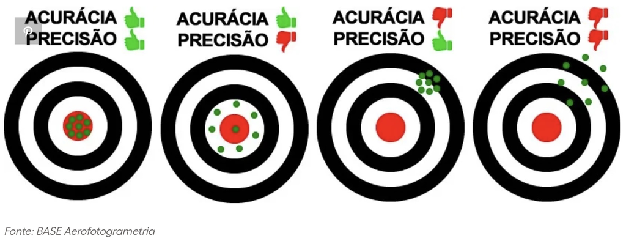

Acurácia = ausência de viés de um estimador. Precisão: Eficiência de um estimador.

## Consistência

**Estimador Consistente**

- Um estimador $\hat{\theta}_n$ é consistente para $\theta$ se, à medida que o tamanho da amostra $n$ aumenta, o estimador converge de alguma forma para o valor verdadeiro do parâmetro.
- Veremos esse tópico em mais detalhes na disciplina devido à sua extrema importância em econometria.

## Exemplo

**Propriedades de estimadores**

- Vamos analisar o viés dos estimadores de de máxima verossilhança da média ($\mu$) e da variância $\sigma^2$ de uma distribuição normal.
- Para isso, vamos revisar rapidamente 3 propriedades do valor esperado de uma variável aleatória.

## Propriedades de $E(X)$

**3 Propriedades**

#### Linearidade:

$$\begin{align}
E[X_1 + X_2 + \ldots + X_n ] &= E[X_1] + E[X_2] + \ldots + E[X_N] \\
E\left[\sum_{i=1}^n X_i\right] &= \sum_{i=1}^n E[X_i]
\end{align}$$

#### Valor Esperado de uma Constante:

$$E[c] = c \rightarrow E[cX] = cE[X]$$

#### Valor Esperado do Produto de Variáveis Independentes

$$E[X_1 X_2] = E[X_1]E[X_2]$$

## Viés do estimador de $\mu$

**Estimador não-viesado**

$$\begin{align}
E[\bar{x}] &= E\left[\frac{\sum_{i=1}^n x_i}{n}\right] \\
&= \frac{1}{n} \sum_{i=1}^n E[x_i] \\
&= \frac{1}{n} \sum_{i=1}^n \mu \\
&= \frac{1}{n} \cdot n\mu \\
&= \mu
\end{align}$$

## Viés do Estimador de $\sigma^2$

**Estimador viesado**

$$\begin{align}
E[\hat{\sigma}^2] &= E\left[\frac{1}{n} \sum_{i=1}^n (x_i - \bar{x})^2\right] \\
&= \frac{n-1}{n}\sigma^2
\end{align}$$

Isso mostra que $\hat{\sigma}^2$ é viesado.

Para corrigir esse viés, multiplicamos o estimador por
$$\frac{n}{n-1}$$
, obtendo o estimador corrigido:

$$\boxed{s^2 = \frac{1}{n-1} \sum_{i=1}^n (x_i - \bar{x})^2}$$
Esse estimador é não viesado, pois $E[s^2] = \sigma^2$.

# Fundamento Teórico

## Modelos de Regressão Linear

**Por que nos preocupamos tanto com modelos de regressão linear?**

- Uma das razões é que os estimadores de mínimos quadrados ordinários de modelos de regressão linear são bons estimadores, se certas hipóteses forem verdadeiras.
- Em termos **probabílisticos**, o verdadeiro objetivo da regressão linear é entender como a média da variável dependente $Y$ se comporta para diferentes valores da variável explicativa $X$.
- Isso significa estimar a **Função de Expectativa Condicional (FEC)**: $E[Y \mid X]$
- O método dos Mínimos Quadrados Ordinários é importante porque, entre todas as funções lineares, ele fornece a **melhor aproximação linear da FEC**
- Portanto, entender a FEC é essencial para compreender o que a regressão linear realmente está estimando.

## Função de Expectativa Condicional (FEC)

**Descrição Geral**

A **função de expectativa condicional** (FEC) de uma variável dependente $Y_i$, dado um vetor de variáveis explicativas $X_i \in \mathbb{R}^K$, representa o valor esperado de $Y_i$ para cada possível valor fixado de $X_i$.

Escrevemos:
$$\mathop{E}[Y_i \mid X_i]$$

Que é uma **função** dos valores possíveis de $X_i$ — isto é, para cada valor de $X_i$, a FEC nos fornece a média populacional correspondente de $Y_i$.

Exemplos:

- $\mathop{E}\left[ \text{Renda}_i \mid \text{Educação}_i \right]$
- $\mathop{E}\left[ \text{Salário}_i \mid \text{Gênero}_i \right]$

## Função de Expectativa Condicional (FEC)

**Definição Formal**

Seja $Y_i$ uma variável aleatória contínua com densidade condicional $f_{Y \mid X}(t \mid X_i = x)$.

A função de expectativa condicional de $Y_i$ dado $X_i = x$ é definida como:

$$\mathop{E}[Y_i \mid X_i = x] = \int_{-\infty}^{\infty} t \cdot f_{Y \mid X}(t \mid x)\, dt$$

Ou seja, estamos calculando a média de $Y_i$ condicional à informação de que $X_i = x$, ponderando os valores possíveis de $Y_i$ pela sua densidade condicional.

**Importância:**

- A FEC é um **objeto populacional** — não depende de uma amostra, mas da distribuição verdadeira da população.
- Ela serve como ponto de partida para a formulação do modelo de regressão linear: queremos estimar ou aproximar essa função com base em dados.

## Função de Expectativa Condicional e Regressão Linear

**Teorema 1 — Linearidade da FEC**

Se a função de expectativa condicional é linear, isto é:

$$\mathop{E}[Y_i \mid X_i] = \beta_0 + \beta_1 X_i,$$

então essa própria função é a **função de regressão linear populacional**.  
Nesse caso, não há aproximação — estamos modelando a FEC exatamente.

## Função de Expectativa Condicional e Regressão Linear

**Teorema 2 — Melhor preditor linear**

A função de regressão linear populacional é o **melhor preditor linear** de $Y_i$ dado $X_i$, no sentido do **erro quadrático médio (EQM) mínimo** entre todas as funções lineares.

## Função de Expectativa Condicional e Regressão Linear

**Teorema 3 — Melhor aproximação linear da FEC**

Mesmo quando $\mathop{E}[Y_i \mid X_i]$ **não é linear**, a função de regressão linear populacional fornece a **melhor aproximação linear** da FEC (novamente, no sentido de erro quadrático médio):

$$\beta_0 + \beta_1 X_i = \mathop{argmin}_{a, b} \; \mathbb{E} \left[ \left( \mathop{E}[Y_i \mid X_i] - (a + b X_i) \right)^2 \right]$$

- O Teorema 3 justifica o uso da regressão linear **mesmo quando a relação entre $Y$ e $X$ não é linear**: isto é, a regressão linear é a **melhor reta possível** para resumir a média condicional.

## Distribuições Condicionais

[figure not shown]

Figura 1: Distribuições condicionais de $Y_i$ dado $X_i = x$, para $x = 8,...,22$. Cada curva representa a distribuição de $Y_i$ em um subgrupo da população com o mesmo nível de $X_i$ (anos de educação).

## Função de Expecativa Condicional

[figure not shown]

Figura 2: Estimativa empírica da função de expectativa condicional $E[Y_i | X_i]$. Os pontos brancos representam a média de $Y_i$ para cada valor de $X_i$; a linha branca conecta essas médias e ilustra a CEF.

## Função de Expecativa Condicional

[figure not shown]

Figura 3: A função de expectativa condicional $E[Y_i | X_i]$ como linha que conecta as médias condicionais. O fundo mostra as distribuições de $Y_i$ para cada valor de $X_i$, agora sem preenchimento para destacar a FEC.

## Função de Expecativa Condicional

**Por que a FEC?**

- A **função de expectativa condicional (FEC)** é o principal objeto de interesse na análise de regressão, porque ela resume a tendência central da variável dependente $Y$ dada a informação disponível sobre a variável explicativa $X$.
- Como já vimos, entender $E[Y \mid X]$ é mais eficiente do que entender a distribuição conjunta de $Y$ e $X$, pois $E[Y \mid X]$ descreve como a média da população, ou seja de $Y$, muda com $X$.

## Função de Expectativa Condicional e Regressão Linear Populacional

[figure not shown]

Figura 4: Comparação entre a função de expectativa condicional $E[Y_i | X_i]$ (linha cinza escura) e a função de regressão linear populacional (reta laranja). A regressão linear fornece a melhor aproximação linear da FEC.

## Modelo de Regressão Linear

**Fundamento Teórico**

A função de regressão linear populacional aproxima a função de expectativa condicional $E[Y_i \mid X_i]$ **da melhor forma possível entre todas as retas**, no sentido de minimizar o **erro quadrático médio**:

$$\beta_0 + \beta_1 X_i = \mathop{argmin}_{\beta_0, \beta_1} \; E\left[\left(E[Y_i \mid X_i] - (\beta_0 + \beta_1 X_i)\right)^2\right]$$

Essa é a **justificativa teórica** para o uso da regressão linear: mesmo quando a verdadeira relação entre $Y$ e $X$ não é linear, a regressão linear fornece a **melhor reta** para aproximá-la.

# O modelo de regressão linear simples

## Modelo de Regressão Linear Simples

**Derivação do Modelo**

Suponha que desejamos estimar $E(Y \mid X)$ (FEC) para uma certa população.

Se a FEC for:

$$E(Y \mid X) = \beta_0 + \beta_1 X$$

e definimos

$$\varepsilon = Y - \beta_0 - \beta_1 X,$$

então, podemos escrever:

$$Y = \beta_0 + \beta_1 X + \varepsilon, \qquad E(\varepsilon \mid X) = 0$$

uma vez que:

$$E(\varepsilon \mid X)
= E(Y - \beta_0 - \beta_1 X \mid X)
= E(Y \mid X) - \beta_0 - \beta_1 X
= 0$$

Ou seja, a função de **regressão linear populacional** coincide com a função de **expectativa condicional** — quando a especificação linear é correta.

## Modelo de Regressão Linear Simples

**Derivação do Modelo**

Note que:

$$E(\varepsilon \mid X) = 0
\;\;\;\;\;\Longrightarrow\;\;\;\;\;
E(\varepsilon) = 0 \quad \text{e} \quad E(\varepsilon X) = 0$$

Além disso:

$$E(Y \mid X) = \beta_0 + \beta_1 X
\;\;\;\;\;\Longrightarrow\;\;\;\;\;
\beta_1 = \frac{\text{Cov}(X, Y)}{\text{Var}(X)}
\quad \text{e} \quad
\beta_0 = E(Y) - \beta_1 E(X)$$

Nosso objetivo é **estimar $\beta_0$ e $\beta_1$** a partir de uma amostra $\{(Y_i, X_i)\}_{i=1}^n$ retirada da população.

## Modelo de Regressão Linear Simples

**Processo Gerador dos Dados**

Assumimos que os dados observados sobre a relação entre $y_i$ e $x_i$ são gerados por um processo linear com um componente aleatório:

$$y_i = \beta_0 + \beta_1 x_i + \varepsilon_i$$

- Os coeficientes $\beta_0$ e $\beta_1$ são parâmetros **populacionais desconhecidos**.
- O termo $\varepsilon_i$ representa um erro aleatório.

## Modelo de Regressão Linear Simples

**Por que incluímos o termo de erro $\varepsilon_i$?**

O erro aleatório $\varepsilon_i$ cumpre o papel de capturar tudo que afeta $y_i$ e que não está incluído explicitamente no modelo:

- **Omissão de variáveis relevantes**: fatores que influenciam $y_i$ além de $x_i$.
- **Erros de medição** na variável dependente.
- **Choques aleatórios**

## Modelo de Regressão Linear Simples

**Modelo = Aproximação da Realidade**

- Essa formulação nos permite pensar o modelo de regressão linear como uma aproximação do processo aleatório real que gerou os dados.
- Cabe ao pesquisador avaliar se essa aproximação é adequada para os objetivos do estudo e para as características dos dados observados.

## Componentes do modelo simples

**O que cada símbolo representa**

- $y$: variável dependente ou explicada.
- $x$: variável independente, explicativa ou preditora.
- $\beta_0$: intercepto, $E(y \mid x = 0)$.
- $\beta_1$: inclinação, isto é, a variação em $E(y)$ associada a uma unidade de variação em $x$.
- $u$: termo de erro, que capta todos os demais determinantes de $y$ não presentes em $x$.

## Terminologia para $x$ e $y$

**Nomes usados em regressão**

| $x$ | $y$ |
| --- | --- |
| variável independente | variável dependente |
| variável explicativa | variável explicada |
| variável preditora | variável predita |
| regressor | regressando |
| variável de controle | variável resposta |

Esses nomes enfatizam papéis diferentes — causal, preditivo ou de controle, por exemplo. A mesma terminologia se estende naturalmente à regressão múltipla, com vários regressores.

## Modelo de Regressão Linear Simples

**Hipóteses**

| Hipótese | Conteúdo |
| --- | --- |
| **H1 — Modelo econométrico** | $y_i=\beta_0+\beta_1x_i+\varepsilon_i$, para $i=1,\ldots,n$. |
| **H2 — Exogeneidade estrita** | $E(\varepsilon_i\mid\mathbf{x})=0$, para $i=1,\ldots,n$. |
| **H3 — Homocedasticidade condicional** | $\operatorname{Var}(\varepsilon_i\mid\mathbf{x})=\sigma^2$, para $i=1,\ldots,n$. |
| **H4 — Erros condicionalmente não correlacionados** | $\operatorname{Cov}(\varepsilon_i,\varepsilon_j\mid\mathbf{x})=0$, para $i\ne j$. |
| **H5 — Variação em $x$** | $x_i\ne x_j$, para algum par $i\ne j$. |
| **H6 — Normalidade condicional dos erros** | $\varepsilon_i\mid\mathbf{x}\sim N(0,\sigma^2)$, para $i=1,\ldots,n$. |

## Nota histórica

**Francis Galton e “regressão”**

- Em 1889, Francis Galton estudou a relação entre a altura de pais e filhos.
- Pais altos tendiam a ter filhos altos, mas, em média, não tão altos quanto os pais;
- Pais baixos tendiam a ter filhos baixos, mas, em média, não tão baixos quanto os pais.
- Ele descreveu esse fenômeno como **regressão em direção à média**.
- O termo “regressão” deriva dessa observação, hoje, análise de regressão é um método geral para estudar relações lineares.

# Mínimos quadrados ordinários

## MQO e outras retas

Considere um conjunto de dados simulados para $y_i$ e $x_i$

[figure not shown]

## MQO e outras retas

Para uma reta qualquer $\left(\hat{y} = \hat{\beta}_0 + \hat{\beta}_1 x\right)$:

[figure not shown]

## MQO e outras retas

Para uma reta qualquer $\left(\hat{y} = \hat{\beta}_0 + \hat{\beta}_1 x\right)$, podemos calcular os resíduos: $\hat{\varepsilon}_i = y_i - \hat{y}_i$.

[figure not shown]

## MQO e outras retas

Para uma reta qualquer $\left(\hat{y} = \hat{\beta}_0 + \hat{\beta}_1 x\right)$, podemos calcular os resíduos: $\hat{\varepsilon}_i = y_i - \hat{y}_i$.

[figure not shown]

## MQO e outras retas

Para uma reta qualquer $\left(\hat{y} = \hat{\beta}_0 + \hat{\beta}_1 x\right)$, podemos calcular os resíduos: $\hat{\varepsilon}_i = y_i - \hat{y}_i$.

[figure not shown]

## MQO e outras retas

A soma dos quadrados dos resíduos (SQR), $\left(\sum_i \hat{\varepsilon}_i^2\right)$, eleva os resíduos ao quadrado: resíduos maiores recebem penalidades maiores.

[figure not shown]

## MQO e outras retas

A estimativa de MQO é a combinação de $\hat{\beta}_0$ e $\hat{\beta}_1$ que minimiza a SQR.

[figure not shown]

## Formalmente

**Derivando os estimadores de $\beta_0$ e $\beta_1$**

Sejam $\hat{\beta}_0$ e $\hat{\beta}_1$ os estimadores de $\beta_0$ e $\beta_1$.

Definimos:

- **Valores ajustados (*fitted values*):**

$$\hat{Y}_i = \hat{\beta}_0 + \hat{\beta}_1 X_i$$
- **Resíduos:**

$$\hat{\varepsilon}_i = Y_i - \hat{Y}_i = Y_i - \hat{\beta}_0 - \hat{\beta}_1 X_i$$

para todo $i = 1, \dots, n$.

Naturalmente, temos:

$$Y_i = \hat{\beta}_0 + \hat{\beta}_1 X_i + \hat{\varepsilon}_i
= \hat{Y}_i + \hat{\varepsilon}_i$$

Escolhemos $\hat{\beta}_0$ e $\hat{\beta}_1$ de modo a **minimizar a soma dos quadrados dos resíduos** (RSS):

$$SQR = \sum_{i=1}^{n} \left( Y_i - \hat{\beta}_0 - \hat{\beta}_1 X_i \right)^2$$

Ou seja, determinamos:

$$\hat{\beta}_0, \; \hat{\beta}_1
= \arg \min_{\beta_0, \beta_1}
\sum_{i=1}^{n} \left( Y_i - \beta_0 - \beta_1 X_i \right)^2$$

Este é o **método dos mínimos quadrados ordinários (OLS)**.

## Estimadores de MQO

**Condições de Primeira Ordem**

A teoria elementar de otimização diz que $\hat{\beta}_0$ e $\hat{\beta}_1$ devem satisfazer as condições de primeira ordem necessárias:

P
$$\frac{\partial SQR}{\partial \hat{\beta}_0} \Bigg|_{\hat{\beta}_0^, \hat{\beta}_1}
= -2 \sum_{i=1}^{n} \left( Y_i - \hat{\beta}_0 - \hat{\beta}_1 X_i \right) = 0$$

$$\frac{\partial SQR}{\partial \hat{\beta}_1} \Bigg|_{\hat{\beta}_0, \hat{\beta}_1}
= -2 \sum_{i=1}^{n} \left( Y_i - \hat{\beta}_0 - \hat{\beta}_1 X_i \right) X_i = 0$$

Resolvendo as condições de primeira ordem do OLS, obtemos:

1. Da primeira condição:

$$\begin{align*}
\sum_{i=1}^{n} Y_i - n \hat{\beta}_0 - \hat{\beta}_1 \sum_{i=1}^{n} X_i &= 0 \\
\bar{Y} - \hat{\beta}_0 - \hat{\beta}_1 \bar{X} &= 0 \quad (\text{dividindo por n})
\end{align*}$$

o que implica:

$$\boxed{\hat{\beta}_0 = \bar{Y} - \hat{\beta}_1 \bar{X}}$$

2. Substituindo em (2), temos:

$$\sum_{i=1}^{n} \Big(Y_i - (\bar{Y} - \hat{\beta}_1 \bar{X}) - \hat{\beta}_1 X_i \Big) X_i = 0$$

ou seja,

$$\sum_{i=1}^{n} \Big[ (Y_i - \bar{Y}) - \hat{\beta}_1(X_i - \bar{X}) \Big] X_i = 0$$

o que se reescreve como:

$$\sum_{i=1}^{n} (Y_i - \bar{Y}) X_i
- \hat{\beta}_1 \sum_{i=1}^{n} (X_i - \bar{X}) X_i = 0$$

portanto:

$$\boxed{\hat{\beta}_1 = \frac{\sum_{i=1}^{n} (Y_i - \bar{Y}) X_i}{\sum_{i=1}^{n} (X_i - \bar{X}) X_i}}$$

## Estimadores de MQO

**Condições de Segunda Ordem**

Pode-se mostrar que a condição de segunda ordem também é satisfeita (detalhes omitidos).

## Estimadores de Mínimos Quadrados Ordinários

**Formas Básicas**

$$\hat{\beta}_1 =\frac{\sum_{i=1}^{n} (Y_i - \bar{Y}) X_i}{\sum_{i=1}^{n} (X_i - \bar{X}) X_i}$$

$$\hat{\beta}_0 = \bar{Y} - \hat{\beta}_1 \bar{X}$$

## Estimadores de MQO

**Formas Alternativas de $\hat{\beta}_1$:**

$$\hat{\beta}_1 = \frac{\sum_{i=1}^{n} (X_i - \bar{X})(Y_i - \bar{Y})}{\sum_{i=1}^{n} (X_i - \bar{X})^2}$$

ou,

$$\boxed{\hat{\beta}_1 = \sum_{i=1}^{n} w_i Y_i}$$

sendo $w_i = \dfrac{X_i - \bar{X}}{\sum_{i=1}^{n} (X_i - \bar{X})^2}$.

Esta forma mostra que podemos escrever $\hat{\beta}_1$ como um **estimador linear** de $Y_i$, sendo fácil ver o mesmo para $\hat{\beta}_0$

## Erros e resíduos

**Uma distinção fundamental**

**Erro $\varepsilon_i$**

- diferença entre $y_i$ e os valores populacionais;
- depende dos parâmetros desconhecidos $\beta_0$ e $\beta_1$;
- não é observável.

**Resíduo $\hat{\varepsilon}_i$**

- diferença entre $y_i$ e $\hat{y}_i$ que constituem reta estimada;
- é observável depois de estimar MQO;
- é usado em diagnósticos de heterocedasticidade, autocorrelação e observações atípicas.

# Propriedades dos Estimadores de MQO

## Estimadores de MQO

**O que precisamos saber sobre um estimador?**

- Precisamos saber qual é a sua distribuição de probabilidade, também chamada de **distribuição amostral**.

#### E por que precisamos saber sua distribuição?

- Porque **não** podemos realizar inferência, como construir intervalos de confiança e realizar testes de hipóteses, a menos que saibamos algo sobre a sua distribuição.
- Inicialmente, vamos verificar $E\left[ \hat{\beta}_1 | x \right]$, $E\left[ \hat{\beta}_0 | x \right]$, $V\left[ \hat{\beta}_1 | x \right]$ e $V\left[ \hat{\beta}_0 | x \right]$

## Estimadores de MQO

**Formas Alternativas de $\hat{\beta}_1$ e $\hat{\beta}_0$:**

$\hat{\beta}_1$ pode ser escrito como:

$$\hat{\beta}_1 = \beta_1 + \dfrac{\sum_i \left( x_i - \overline{x} \right) \varepsilon_i}{\sum_i \left( x_i - \overline{x} \right)^2}$$

e $\hat{\beta}_0$ como:

$$\hat{\beta}_0 = \beta_0 + (\beta_1 - \hat{\beta}_1)\bar{x} + \bar{\varepsilon}$$

#### Prova para $\hat{\beta}_1$

$$\begin{aligned}
\hat{\beta}_1
&= \dfrac{\sum_i\left(y_i-\overline{y}\right)\left(x_i-\overline{x}\right)}{\sum_i\left(x_i -\overline{x}\right)^2} \\
&= \dfrac{\sum_i\left(\left[ \beta_0 + \beta_1 x_i + \varepsilon_i \right]- \left[ \beta_0 + \beta_1 \overline{x} + \overline{\varepsilon} \right] \right)\left(x_i-\overline{x}\right)}{\sum_i\left(x_i -\overline{x}\right)^2} \\
&= \dfrac{\sum_i\left(\beta_1 \left[ x_i - \overline{x} \right] + \left[\varepsilon_i - \overline{\varepsilon}\right] \right)\left(x_i-\overline{x}\right)}{\sum_i\left(x_i -\overline{x}\right)^2} \\
&= \dfrac{\sum_i\left(\beta_1 \left[ x_i - \overline{x} \right]^2 + \left[ x_i - \overline{x} \right] \left[\varepsilon_i - \overline{\varepsilon}\right]\right)}{\sum_i\left(x_i -\overline{x}\right)^2} \\
&= \beta_1 + \dfrac{\sum_i\left(x_i - \overline{x}\right) \left(\varepsilon_i - \overline{\varepsilon}\right)}{\sum_i\left(x_i -\overline{x}\right)^2} \\
&= \beta_1 + \dfrac{\sum_i\left(x_i - \overline{x}\right) \varepsilon_i - \overline{\varepsilon} \sum_i\left(x_i - \overline{x}\right)}{\sum_i\left(x_i -\overline{x}\right)^2} \\
&= \beta_1 + \dfrac{\sum_i\left(x_i - \overline{x}\right) \varepsilon_i - \overline{\varepsilon} \left(\sum_i x_i - \sum_i \overline{x}\right)}{\sum_i\left(x_i -\overline{x}\right)^2} \\
&= \beta_1 + \dfrac{\sum_i\left(x_i - \overline{x}\right) \varepsilon_i - \overline{\varepsilon} \left(\sum_i x_i - n \overline{x}\right)}{\sum_i\left(x_i -\overline{x}\right)^2} \\
&= \beta_1 + \dfrac{\sum_i\left(x_i - \overline{x}\right) \varepsilon_i - \overline{\varepsilon} \color{#e64173}{\left(\sum_i x_i - \sum_i x_i\right)}}{\sum_i\left(x_i -\overline{x}\right)^2} \\
\hat{\beta}_1 &= \beta_1 + \dfrac{\sum_i\left(x_i - \overline{x}\right) \varepsilon_i}{\sum_i\left(x_i -\overline{x}\right)^2}
\end{aligned}$$

## Propriedades dos Estimadores de MQO

**$E\left[ \hat{\beta}_1 | x \right]$ e $E\left[ \hat{\beta}_0 | x \right]$**

#### $E\left[ \hat{\beta}_1 | x \right]$

*Prova:*

$$\begin{align*}
E\left[ \hat{\beta}_1 | x \right] &= \mathop{\boldsymbol{E}}\left[ \beta_1 + \dfrac{\sum_i\left(x_i - \overline{x}\right)
\varepsilon_i}{\sum_i\left(x_i -\overline{x}\right)^2} \middle| x \right] \\[0.5em]
&= \beta_1 + \mathop{\boldsymbol{E}}\left[ \dfrac{\sum_i\left(x_i - \overline{x}\right) \varepsilon_i}{\sum_i\left(x_i -\overline{x}\right)^2} \middle| x \right] \\[0.5em]
&= \beta_1 + \dfrac{\sum_i\left(x_i - \overline{x}\right)}{\sum_i\left(x_i -\overline{x}\right)^2} \color{#e64173}{\underbrace{\mathop{\boldsymbol{E}}\left[\varepsilon_i \middle| x \right]}_{=0}} \\[0.5em]
E\left[ \hat{\beta}_1 | x \right] &= \beta_1
\end{align*}$$

#### $E\left[ \hat{\beta}_0 | x \right]$

$$E\left[ \hat{\beta}_0 | x \right] = \beta_0$$

*Prova:* Fico como exercício

- Portanto, Os **estimadores de MQO** dos parâmetros $\beta_0$ e $\beta_1$ são **não-viesados**, sob a hipótese de **exogeneidade**.

## Propriedades dos Estimadores de MQO

**$V\left[ \hat{\beta}_1 | x \right]$ e $V\left[ \hat{\beta}_0 | x \right]$**

#### $V\left[ \hat{\beta}_1 | x \right]$

$$V\left[ \hat{\beta}_1 | x \right] = \frac{\sigma^2}{\sum_i\left(x_i -\bar{x}\right)^2}$$

#### $V\left[ \hat{\beta}_0 | x \right]$

$$V\left[ \hat{\beta}_0 \mid x \right] = \sigma^2 \left[
\frac{1}{n}+\frac{\bar{x}^2}{\sum_i\left(x_i-\bar{x}\right)^2}
\right]$$

## Estimadores de MQO

**Estática Comparativa**

- Quanto maior $V(e_i \mid \mathbf{x}) = \sigma^2$, maior $V\left[ \hat{\beta} | x \right]$

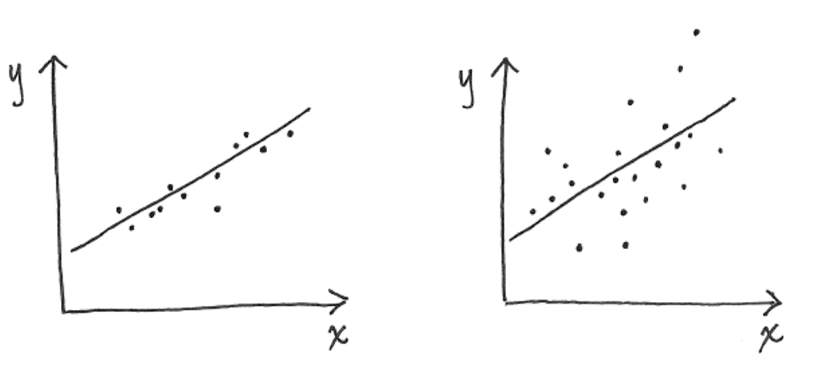

Variância do erro.

- Quanto maior $\sum_i\left(x_i -\bar{x}\right)^2$, menor $V\left[ \hat{\beta} | x \right]$

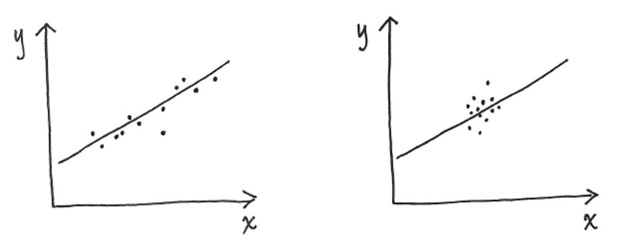

Variância de $x$.

- Quanto maior $N$, menor $V\left[ \hat{\beta} | x \right]$

## Propriedades dos Estimadores de MQO

**Teorema de Gauss-Markov**

Dadas as hipóteses **H1–H5**, os estimadores de mínimos quadrados $\hat{\beta}_0$ e $\hat{\beta}_1$ são **BLUE** (*Best Linear Unbiased Estimators*): têm a menor variância entre os estimadores lineares não viesados de $\beta_0$ e $\beta_1$, condicionalmente aos valores observados de $x$.

#### Considerações

1. “Melhores” significa melhores **na classe dos estimadores lineares não viesados**. O teorema não os compara com todos os estimadores possíveis.
2. H2 sustenta a ausência de viés; H3, H4 e H5 completam as condições que garantem eficiência dentro dessa classe.
3. Se alguma dessas hipóteses falhar, o teorema deixa de garantir a propriedade BLUE; isso não demonstra, por si só, que MQO não seja BLUE em um caso particular.
4. H6 não é necessária para Gauss-Markov. Ela é usada para inferência exata em pequenas amostras.

## Estimador da Variância do Erro

**Estimador de $\sigma^2$**

- A variância do termo do erro aleatório, $\sigma^2$ é um parâmetro cuja estimação é fundamental para os procedimentos de inferência para o modelo de regressão linear simples.
- A variância condicional do erro aleatório $e_i$ é:

$$V(e_i \mid x) = \sigma^2 = E\{[e_i - E(e_i \mid x)]^2 \mid x\} = E(e_i^2 \mid x),$$

se a suposição $E(e_i \mid x) = 0$ for correta. Como a “expectativa” é um valor médio, podemos considerar estimar $\sigma^2$ como a média dos erros ao quadrado:

$$\sigma^2 = \frac{\sum e_i^2}{N}.$$

Infelizmente, esta fórmula não é útil, pois os erros aleatórios $e_i$ não são observáveis.

No entanto, embora os erros aleatórios sejam desconhecidos, temos um análogo a eles — os **resíduos dos mínimos quadrados**.

Recorde-se que os erros aleatórios são definidos como:

$$e_i = y_i - \beta_0 - \beta_1 x_i.$$

E que os resíduos dos mínimos quadrados são obtidos substituindo os parâmetros desconhecidos por suas estimativas de MQO:

$$\hat{e}_i = y_i - \hat{y}_i = y_i - \hat{\beta}_0 - \hat{\beta}_1 x_i.$$

De modo que:

$$\hat{\sigma}^2 = \frac{\sum \hat{e}_i^2}{N}.$$

Esse estimador, embora bastante satisfatório em amostras grandes, é **viesado** como estimador de $\sigma^2$.

Mas há uma correção simples que produz um estimador não viesado:

$$\boxed{\hat{\sigma}^2 = \frac{\sum_i^n(y_i - \hat{y}_i)^2}{N - 2} =\frac{\sum \hat{e}_i^2}{N - 2}}$$

O número $2$ subtraído no denominador corresponde ao número de parâmetros de regressão $(\beta_1, \beta_2)$ no modelo, e essa correção torna o estimador de $\sigma^2$ não viesado, de modo que $E(\hat{\sigma}^2 \mid x) = \sigma^2.$

## Distribuição dos Estimadores de MQO

**Distribuição Amostral de $\hat{\beta}_1$ e $\hat{\beta}_0$**

Com H6, isto é, normalidade condicional dos erros, as distribuições amostrais condicionais dos estimadores de MQO também são normais.

#### Distribuições exatas sob H1–H6

Como os estimadores são combinações lineares de observações normalmente distribuídas, dado $x$:

$$\begin{align*}
\hat{\beta}_1\mid x &\sim N \left(\beta_1, \frac{\sigma^2}{\sum_i (x_i - \bar{x})^2} \right) \\
\hat{\beta}_0\mid x &\sim N \left(\beta_0, \sigma^2\left[\frac{1}{n}+
\frac{\bar{x}^2}{\sum_i (x_i - \bar{x})^2}\right] \right).
\end{align*}$$

Como $\sigma^2$ é desconhecida, substituímos a variância teórica pelo erro-padrão estimado. Para $j\in\{0,1\}$:

$$\frac{\hat{\beta}_j-\beta_j}
{\widehat{ep}\!\left(\hat{\beta}_j\right)}
\sim t_{n-2}.$$

## Distribuição dos Estimadores de MQO

**E se os erros não tiverem distribuição normal?**

- **Q:** Se os erros não seguirem uma distribuição normal, podemos dizer algo sobre a distribuição dos estimadores de MQO?
- **R:** Sim, às vezes.

#### Inferência em amostras grandes

Sem normalidade exata dos erros, a inferência costuma apoiar-se em aproximações de grandes amostras. Em condições apropriadas, as estatísticas de MQO podem ser tratadas aproximadamente como normais.

O fundamento formal dessa aproximação — consistência, distribuição assintótica e suas condições — será desenvolvido mais adiante na disciplina.

## Distribuição dos Estimadores de MQO

**“Quão grande é suficiente?”**

- **R:** Pergunta de 1 milhão.
- Não existe uma resposta única e válida para todas as situações.
- Depende de:
  - A distribuição dos erros é simétrica? assimétrica? Forte assimetria é o pior cenário..
  - Distribuição de $x_i$.
- Não há um ponto de corte universal: valores como $N=30$ ou $N=50$ não garantem uma boa aproximação.
- Em resumo: depende do problema e não substitui a análise das hipóteses do modelo.

## Medida da Qualidade do Ajuste

**Decomposição da Variância de $Y_i$**

- No caso de um modelo de regressão linear, podemos decompor $V(Y_i)$ como:

$$V(Y) =
\underbrace{E[V(Y|X)]}_{\text{variância dentro dos grupos}} +
\underbrace{V(E[Y|X])}_{\text{variância entre grupos}}$$

ou, de outra forma:

$$Y_i = E[Y_i \mid X_i] + \varepsilon_i
\tag{1}$$

- sendo $E[Y_i \mid X_i] = \beta_0 + \beta_1 X_i$, a variação sistemática em $Y_i$ explicada por $X_i$ e $\varepsilon_i$ a variação aleatória ou não explicada em $Y_i$.
- Embora ambas essas partes sejam não observáveis, podemos estimar os parâmetros desconhecidos $\beta_1$ e $\beta_2$ e, de forma análoga à Equação 1, decompor o valor de $y_i$ em:

$$\begin{align*}
y_i &= (\hat{\beta}_0 + \hat{\beta}_1 x_i) + (y_i - \hat{y}_i) \\
y_i &= \hat{y}_i + \hat{\varepsilon}_i \\
y_i - \bar{y}_i &= \hat{y}_i - \bar{y}_i + \hat{\varepsilon}_i \\
\sum_i^{n} (y_i - \bar{y}_i)^2 &= \sum_i^{n} (\hat{y}_i - \bar{y}_i)^2 + \sum_i (\hat{\varepsilon}_i)^2
\end{align*}$$

- $\sum_i^{n} (y_i - \bar{y}_i)^2$ = Soma de Quadrados Total (SQT) = medida da variação total de $y_i$ em relação à média.
- $\sum_i^{n} (\hat{y}_i - \bar{y}_i)^2$ = Soma de Quadrados do Modelo de Regressão (SQM) = parte da variação total de $y_i$ em torno de sua média explicada por $X_i$ ou pelo modelo de regressão, também conhecida como soma de quadrados explicada.
- $\sum_i^{n} (\hat{\varepsilon}_i)^2$ = Soma de Quadrados do Erro (SQR) = parte da variação total de $y$ em torno de sua média que não é explicada pelo modelo de regressão. Também conhecida como soma dos quadrados não explicada e soma dos quadrados resíduos.
- Assim, podemos escrever:

$$SQT = SQM + SQR$$

- Essa decomposição da variação total de $y$ em uma parte explicada pelo modelo de regressão e outra não explicada nos permite definir uma medida, denominada **coeficiente de determinação**, ou $R^2$, que representa a proporção da variação de $y$ explicada por $x$ ou pelo modelo de regressão:

$$\boxed{R^2 = \frac{SQM}{SQT} = 1 - \frac{SQR}{SQT}}$$

- Portanto $0 < R^2 < 1$ e é a proporção da variação total em $y$ explicada pelo modelo de regressão, sendo utilizada como uma medida da qualidade do ajuste.
- Entretanto, $R^2$ é uma medida limitada, pois simplesmente adicionar mais variáveis explicativas $x$ ao modelo, aumenta o $R^2$.

## Intervalos de Confiança

**Descrição**

- Sob H1–H6, a estatística $t$ tem distribuição exata em pequenas amostras e podemos construir intervalos de confiança para $\beta_0$ e $\beta_1$.
- Usando o fato que:

$$\frac{\hat{\beta}_j-\beta_j}{\widehat{ep}\!\left(\hat{\beta}_j\right)}
\sim t_{n-2}, \qquad j\in\{0,1\}$$

- Um intervalo bilateral de 95% para $\beta_j$, com $j\in\{0,1\}$, é:

$$\hat{\beta}_j \pm t_{n-2,0.975}\times \widehat{ep}\!\left(\hat{\beta}_j\right).$$

- O quantil $t_{n-2,0.975}$ é o valor crítico bilateral de 95% com $n-2$ graus de liberdade.
- podemos calcular facilnente o quantil $c$ em R:

```r
# número de observações
n <- 30
# graus de liberdade
gl <- n - 2
# valor crítico = quantil da distribuição t com n - 2 graus de liberdade
c <- qt(0.975, gl)
c
```

```
[1] 2.048407
```

## Testes de Hipóteses

**Descrição**

- Sob H1–H6, a estatística $t$ tem distribuição exata em pequenas amostras e podemos testar hipóteses sobre $\beta_0$ ou $\beta_1$.
- Usando o fato que:

$$\frac{\hat{\beta}_j-\beta_j}{\widehat{ep}\!\left(\hat{\beta}_j\right)}
\sim t_{n-2}, \qquad j\in\{0,1\}$$

- Para testar $H_0:\beta_j=\beta_{j,0}$ contra uma alternativa bilateral, sob $H_0$:

$$\begin{align*}
T_j &= \frac{\hat{\beta}_j-\beta_{j,0}}
{\widehat{ep}\!\left(\hat{\beta}_j\right)}
\sim t_{n-2}, \qquad j\in\{0,1\}.
\end{align*}$$

- Se o valor-$p$ for menor que $\alpha$, rejeitamos $H_0$.
- Se o valor-$p$ for maior ou igual a $\alpha$, não rejeitamos $H_0$; isso não demonstra que o parâmetro seja igual ao valor hipotetizado.

## Interpretação das Estimativas dos Parâmetros

**Interpretação do Intercepto ($\hat{beta}_0$)**

- $\hat{\beta}_0$: Estimativa de $y$ quado as variáveis preditoras são iguais a zer, $X = 0$.
- $\hat{\beta}_0$: É preciso cuidado na interpretação (principalmente quando há poucas ou nenhuma observação próxima ao eixo $y$, veja fig.). Nem sempre a estimativa faz sentido ou e em diversos casos, não há interesse nesta estimativa.

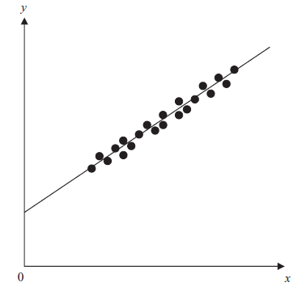

## Interpretação das Estimativas dos Parâmetros

Para $x_i$ sendo uma variável numérica, podemos interpretar $\hat{\beta}_1$ como:

$$\frac{\partial \hat{y_{i}}}{\partial x_{i}} = \hat{\beta}_1$$

Isto é, $\hat{\beta}$ mensura o efeito médio sobre $y_i$ do aumento de uma unidade em $x_i$.

## Interpretação das Estimativas dos Parâmetros

**Interpretação de $\hat{beta}_1$**

Para $x_i$ sendo uma variável numérica, podemos interpretar $\hat{\beta}_1$ como:

$$\frac{\partial \hat{y_{i}}}{\partial x_{i}} = \hat{\beta}_1$$

Isto é, $\hat{\beta}$ mensura o efeito médio sobre $y_i$ do aumento de uma unidade em $x_i$, mantidas as demais variáveis constantes.

# Tópico Extra

## Três perguntas diferentes sobre os dados

**Como ler as hipóteses**

As hipóteses da regressão respondem a perguntas distintas:

- **Como os valores de $x$ surgem?** Podem ser definidos pelo pesquisador ou resultar de um processo aleatório.
- **Como as observações são obtidas?** Podemos observar unidades selecionadas de uma população ou acompanhar observações ao longo do tempo.
- **Qual é a relação entre $x$ e $\varepsilon$?** A exogeneidade requer que os valores de $x$ não sejam correlacionadas com o erro.

Em todos os três casos discutidos a seguir, $y$ é aleatório porque incorpora $\varepsilon$. O que muda é o modo como $x$ e as observações são gerados.

## O que a classificação não garante

**Exogeneidade continua sendo uma hipótese substantiva**

- Tratar os valores de $x$ como fixados não demonstra que eles sejam exógenos. Por exemplo, escolhas definidas pelo pesquisador ainda podem responder a informação não observada sobre o resultado.
- Amostragem aleatória torna observações de unidades diferentes independentes, mas não elimina uma associação entre $x_i$ e $\varepsilon_i$ na própria observação.
- A condição $E(\varepsilon_i)=0$, isoladamente, não basta:

$$E(\varepsilon_i)=0
\not\Rightarrow
E(\varepsilon_i\mid x_i)=0.$$

A defesa da exogeneidade exige argumento sobre o processo gerador dos dados, o desenho de pesquisa e o contexto econômico.

## Três rotas para as propriedades de MQO

**Uma mesma regressão, três formulações**

As três formulações a seguir mantêm o mesmo modelo de regressão simples, mas descrevem maneiras distintas de enunciar hipóteses que justificam as propriedades usuais de MQO.

- **Formulação condicional:** valores de $x$ tratados como dados;
- **$x$ aleatório e independente dos erros:** independência estatística entre $x$ e os erros;
- **Amostragem aleatória:** pares $(y_i,x_i)$ obtidos de uma população.

Elas não são tipos mutuamente exclusivos de exogeneidade, nem requisitos cumulativos. São rotas estilizadas: uma aplicação pode combinar, por exemplo, amostragem de unidades e atribuição aleatória de um tratamento.

## Primeira rota: formulação condicional

**Hipóteses sob exogeneidade estrita**

Nesta tabela, $\mathbf{x}$ reúne os valores observados da única variável explicativa $x$ na amostra.

| Hipótese | Conteúdo |
| --- | --- |
| **H1 — Modelo econométrico** | $y_i=\beta_0+\beta_1x_i+\varepsilon_i$, para $i=1,\ldots,n$. |
| **H2 — Exogeneidade estrita** | $E(\varepsilon_i\mid\mathbf{x})=0$, para $i=1,\ldots,n$. |
| **H3 — Homocedasticidade condicional** | $\operatorname{Var}(\varepsilon_i\mid\mathbf{x})=\sigma^2$, para $i=1,\ldots,n$. |
| **H4 — Erros condicionalmente não correlacionados** | $\operatorname{Cov}(\varepsilon_i,\varepsilon_j\mid\mathbf{x})=0$, para $i\ne j$. |
| **H5 — Variação em $x$** | $x_i\ne x_j$, para algum par $i\ne j$. |
| **H6 — Normalidade condicional dos erros** | $\varepsilon_i\mid\mathbf{x}\sim N(0,\sigma^2)$, para $i=1,\ldots,n$. |

## Como ler H1 e H2

**Modelo e exogeneidade estrita**

Há uma única variável explicativa, $X$; $x_i$ e $x_j$ são valores dessa mesma variável em observações diferentes.

- H1 escreve cada resultado como uma parte sistemática, $\beta_0+\beta_1x_i$, e uma parte não explicada, $\varepsilon_i$.
- H2 exige que a média de $\varepsilon_i$ seja zero, dada toda a amostra de valores de $x$. Ela não afirma que $\varepsilon_i=0$ em cada observação.

$$E(y_i\mid x_i)=\beta_0+\beta_1x_i
\qquad \text{em particular, sob o modelo e a exogeneidade estrita.}$$

- Portanto, a reta $\beta_0+\beta_1x_i$ descreve a média de $y_i$ para dado valor de $x_i$.

## O papel de H3–H6

**Dispersão, identificação e inferência**

- H3: dada a amostra de valores de $x$, os erros têm a mesma variância.
- H4: dada essa amostra, erros de observações diferentes não são correlacionados.
- H5: deve haver variação em $x$; sem ela, não se estima a inclinação $\beta_1$.
- H6: a normalidade condicional dos erros é adicional. Ela permite inferência exata condicional aos valores de $x$ realizados.

Sob H1–H5, MQO é BLUE condicionalmente aos valores de $x$. H6 não é necessária para esse resultado.

## O que H2 implica

**Lei das Expectativas Iteradas**

H2 é uma condição sobre toda a amostra de valores de $x$. Em particular, ela implica que $E(\varepsilon_i\mid x_j)=0$ para quaisquer $i,j$. Assim:

$$E(\varepsilon_i)=E\big[E(\varepsilon_i\mid x_j)\big]=0.$$

Além disso, para qualquer $j$,

$$\begin{aligned}
E(x_j \varepsilon_i)
&=E\big[E(x_j\varepsilon_i\mid x_j)\big] \\
&=E\big[x_jE(\varepsilon_i\mid x_j)\big]=0.
\end{aligned}$$

Como $E(\varepsilon_i)=0$, segue que:

$$\operatorname{Cov}(x_j,\varepsilon_i)
=E(x_j\varepsilon_i)-E(x_j)E(\varepsilon_i)=0.$$

Média condicional zero implica média incondicional zero e covariância zero entre cada erro e cada valor do regressor. O inverso não é verdadeiro em geral.

## Exemplo: vendas e publicidade

**Vendas passadas podem orientar a publicidade corrente**

Considere a regressão entre vendas trimestrais e despesas com publicidade:

$$\text{VENDAS}_t=\beta_0+\beta_1\text{PUBLICIDADE}_t+\varepsilon_t.$$

Suponha que a empresa defina a publicidade no trimestre $t$ a partir das vendas do mesmo trimestre do ano anterior:

$$\text{PUBLICIDADE}_t=f(\text{VENDAS}_{t-4}).$$

No mesmo modelo, as vendas passadas incorporam o choque não observado do período:

$$\text{VENDAS}_{t-4}=\beta_0+\beta_1\text{PUBLICIDADE}_{t-4}+\varepsilon_{t-4}.$$

Logo, a regra de decisão pode transmitir informação desse erro passado para o regressor atual; é plausível que

$$\operatorname{Cov}(\text{PUBLICIDADE}_t,\varepsilon_{t-4})\ne 0.$$

Assim, $E(\varepsilon_{t-4}\mid \text{PUBLICIDADE}_t)=0$ falha. A hipótese de exogeneidade estrita exige $E(\varepsilon_s\mid x_t)=0$ para todos os pares de períodos $s,t$. Este exemplo diz respeito a essa relação entre um erro passado e um regressor futuro, não à correlação entre erros em períodos distintos.

## Segunda rota: $x$ aleatório e independente dos erros

**Modelo com $x$ aleatório e independente**

| Hipótese | Conteúdo |
| --- | --- |
| **Modelo econométrico** | $y_i=\beta_0+\beta_1x_i+\varepsilon_i$, para $i=1,\ldots,n$. |
| **Erro médio zero** | $E(\varepsilon_i)=0$. |
| **Variância constante** | $\operatorname{Var}(\varepsilon_i)=\sigma^2$. |
| **Erros não correlacionados** | $\operatorname{Cov}(\varepsilon_i,\varepsilon_j)=0$ para $i\ne j$. |
| **Independência e variação em $x$** | Todos os erros são estatisticamente independentes dos valores de $x$ na amostra; $x_i$ assume ao menos dois valores distintos. |
| **Normalidade do erro** | $\varepsilon_i\sim N(0,\sigma^2)$. |

## Por que as condicionais desaparecem?

**Independência é mais forte que exogeneidade estrita**

Nesta formulação, $x$ é aleatório. A hipótese adicional é que o processo que gera os valores de $x$ seja estatisticamente independente dos erros. Ela é mais forte do que exigir apenas covariância nula entre uma observação de $x$ e seu erro: todos os erros são independentes dos valores de $x$ na amostra.

Assim, conhecer qualquer $x_j$ não altera a média nem a variância de $\varepsilon_i$:

$$E(\varepsilon_i\mid x_j)=E(\varepsilon_i),
\qquad
\operatorname{Var}(\varepsilon_i\mid x_j)=\operatorname{Var}(\varepsilon_i).$$

Por isso, as hipóteses sobre a média, a variância e a covariância dos erros podem ser escritas sem condicionamento em $x$. Sob as hipóteses anteriores à normalidade, MQO é BLUE. O cálculo usual da regressão e da variância estimada do erro não muda; a normalidade permite inferência exata condicional aos valores de $x$ realizados.

## Exemplo: dois desenhos para o mesmo experimento

**Doses definidas pelo pesquisador**

Antes do experimento, um agrônomo escreve um plano: define qual dose de pesticida será aplicada em cada área e mede a produtividade. Em repetições hipotéticas, ele mantém o mesmo plano de doses; os valores de $x_i$ são tratados como dados.

Este é o desenho condicional: a variação da produtividade é aleatória, dadas as doses escolhidas. As propriedades de MQO são examinadas condicionando nos valores de $x$ definidos. A definição prévia das doses não dispensa a defesa da exogeneidade.

**Doses sorteadas aleatoriamente**

Em vez de seguir um plano fixo, o agrônomo sorteia a dose de cada área antes de aplicá-la. Em uma nova repetição, os sorteios podem gerar outros valores de $x_i$: $x$ é aleatório. Se o sorteio é independente das condições não observadas que afetam a produtividade, ele torna plausível a independência entre doses e erros.

O estimador de MQO é o mesmo nos dois desenhos. O que muda é o processo gerador dos dados e, portanto, a formulação usada para justificar suas propriedades.

## Terceira rota: amostragem aleatória dos pares

**Pares $(y_i,x_i)$ de uma mesma população**

| Hipótese | Conteúdo |
| --- | --- |
| **Modelo econométrico** | $y_i=\beta_0+\beta_1x_i+\varepsilon_i$, para $i=1,\ldots,n$. |
| **Amostra aleatória** | Os pares $(y_i,x_i)$ são independentes e têm a mesma distribuição conjunta. |
| **Exogeneidade** | $E(\varepsilon_i\mid x_i)=0$, para $i=1,\ldots,n$. |
| **Homocedasticidade condicional** | $\operatorname{Var}(\varepsilon_i\mid x_i)=\sigma^2$. |
| **Variação em $x$** | $x_i$ assume pelo menos dois valores distintos. |
| **Normalidade do erro** | $\varepsilon_i\sim N(0,\sigma^2)$. |

## O que a amostragem aleatória muda

**A relação decisiva é a da própria observação**

Em uma amostra aleatória, os pares $(y_i,x_i)$ são extraídos da mesma população; antes de serem observados, tanto $y_i$ como $x_i$ são aleatórios. A independência entre pares distintos implica que, para $i\ne j$, $x_j$ é independente de $\varepsilon_i$.

Assim, as relações entre observações diferentes são obtidas pela própria amostragem. Para avaliar a exogeneidade, resta examinar a relação entre o regressor e o erro da mesma observação:

$$E(\varepsilon_i\mid x_i)=0.$$

Essa condição afirma que os fatores não observados reunidos em $\varepsilon_i$ não estão sistematicamente associados a $x_i$. A amostragem aleatória, por si só, não a garante. Se ela falhar, $x_i$ é endógeno.

A independência dos pares também dispensa uma hipótese separada de erros não correlacionados entre observações diferentes. Sob as hipóteses anteriores à normalidade, MQO é BLUE; a normalidade permite inferência exata condicional aos valores de $x$ realizados.

## Exemplo: amostragem aleatória não elimina endogeneidade

**A relação dentro de cada firma continua decisiva**

Considere uma pesquisa que seleciona firmas aleatoriamente e estima o modelo de custos:

$$\text{CUSTO}_i=\beta_0+\beta_1\text{INSUMOS}_i+\varepsilon_i.$$

A seleção aleatória decide quais firmas entram na pesquisa; ela não decide o uso de insumos dentro de cada firma. Assim, ela torna plausível a independência entre observações de firmas diferentes, mas não elimina a relação entre insumos e características não observadas da própria firma. Suponha que a habilidade gerencial integre $\varepsilon_i$ e que gestores mais habilidosos consigam produzir com menos insumos. Então,

$$\operatorname{Cov}(\text{INSUMOS}_i,\varepsilon_i)<0.$$

Logo, $E(\varepsilon_i\mid\text{INSUMOS}_i)=0$ falha: o uso de insumos é endógeno. O sinal negativo decorre desta história particular; qualquer associação sistemática entre $\text{INSUMOS}_i$ e $\varepsilon_i$ viola a exogeneidade.

## Três mensagens

**Síntese**

- $y_i$ é aleatório nos três casos, pois incorpora $\varepsilon_i$; o que muda é como os valores de $x$ e as observações são gerados.
- Tratar $x$ como fixado, observar uma amostra aleatória ou supor apenas $E(\varepsilon_i)=0$ não demonstra exogeneidade.
- Para interpretar $\beta_1$ como efeito causal, é necessário justificar, com base no processo gerador dos dados e no contexto econômico, a relação entre $x$ e $\varepsilon$.

## Referências

ANGRIST, J. D.; PISCHKE, J.-S. [The Credibility Revolution in Empirical Economics: How Better Research Design Is Taking the Con out of Econometrics](https://doi.org/10.1257/jep.24.2.3). **Journal of Economic Perspectives**, v. 24, n. 2, p. 3–30, 2010.

BERTRAND, M.; MORSE, A. [Information Disclosure, Cognitive Biases, and Payday Borrowing](https://doi.org/10.1111/j.1540-6261.2011.01698.x). **The Journal of Finance**, v. 66, n. 6, p. 1865–1893, 2011.

BROOKS, C. **[Introductory Econometrics for Finance](https://doi.org/10.1017/9781108524872)**. 4. ed. Cambridge: Cambridge University Press, 2019.

CARD, D.; KRUEGER, A. B. [Minimum Wages and Employment: A Case Study of the Fast-Food Industry in New Jersey and Pennsylvania](https://www.jstor.org/stable/2118030). **American Economic Review**, v. 84, n. 4, p. 772–793, 1994.

CHRISTENSEN, G.; MIGUEL, E. [Transparency, Reproducibility, and the Credibility of Economics Research](https://doi.org/10.1257/jel.20171350). **Journal of Economic Literature**, v. 56, n. 3, p. 920–980, 2018.

HILL, R. C.; GRIFFITHS, W. E.; LIM, G. C. **Principles of Econometrics**. 5. ed. Hoboken, NJ: Wiley, 2018.

HONG, Y.; LINTON, O.; SUN, J. **Chapter 1 – Regression Models**. 2025. Disponível em: <https://econometricsandtimeseries.com>.